# Climate Data and Analysis for Lodi, California

Marisa Weinstock

April 7th, 2017

## Introduction

The city of Lodi is located in the Central Valley of California, our nation’s agricultural hub. The Central Valley acts as one large watershed divided into two valleys: the Sacramento Valley in the North and San Joaquin Valley in the South, with alluvial fans emanating from the Cascade Range and the Northern Sierra Nevada. It is the Central Valley’s water network, fertile soil, and extended growing season that make agriculture the primary industry within the Central Valley and one of the major agricultural regions in the entire nation (AMNH). Lodi resides in the San Joaquin Valley, just North of Modesto. The city is best known for being a center of winegrape production, named the “Zinfandel Capital of the World”. Unfortunately, Lodi’s trend of rising minimum temperatures for October and September from 1930 to 1970 illustrated below signify heightening threats to Lodi’s economy, ecology, and reputation as a viticultural city.

[figure not shown]

Lodi Winegrape Commission, 2015

## Methodology

The National Oceanic and Atmospheric Administration provides free and accessible data for Lodi, California (at Station USC00045032), holding records of minimum and maximum temperatures year-round from January 1st, 1893 to January 31st, 1970. This data has been cut to represent January 1st of 1930 to January 31st, 1970 due to a large gap in data. I focus only on minimum temperature to illustrate a particular aspect of climate change’s impact on viticulture. A statistical hypothesis test evaluates the validity of a claim made about a population. This claim that is on trial, in essence, is called the null hypothesis. This creates a p-value that helps to determine the significance of the results. All hypothesis tests ultimately use a p-value to weigh the strength of the evidence (what the data illustrates about the population). A small p-value (typically ≤ 0.05) indicates strong evidence against the null hypothesis, so you are able to reject the null hypothesis and a large p-value (> 0.05) indicates weak evidence against the null hypothesis. Both September and October have strong evidence rejecting the null hypothesis and therefore illustrate significance minimum temperature changes.

### Minimum Temperature Increase in October

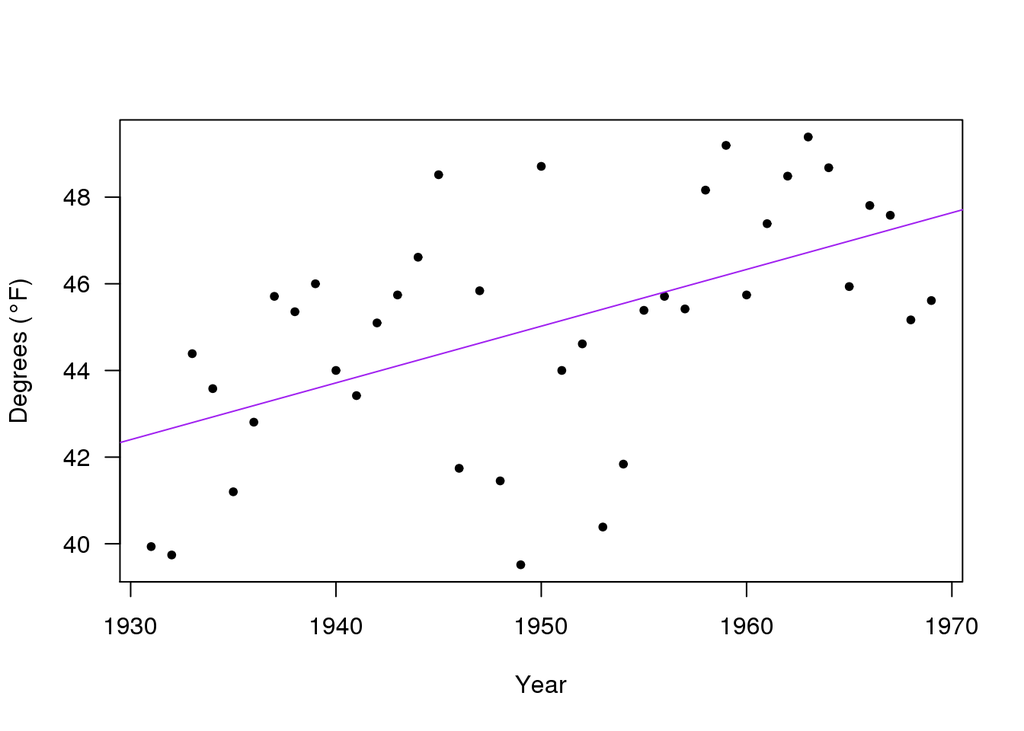

The minimum temperatures within the month of October increase at a slope of 0.13 degress Fahrenheit per year, with a statistically significant probability of <.001. This refutes the null hypothesis and thereby indicates a statistical significance with the relationship between temperature rise and time.

### Minimum Temperature Increase in September

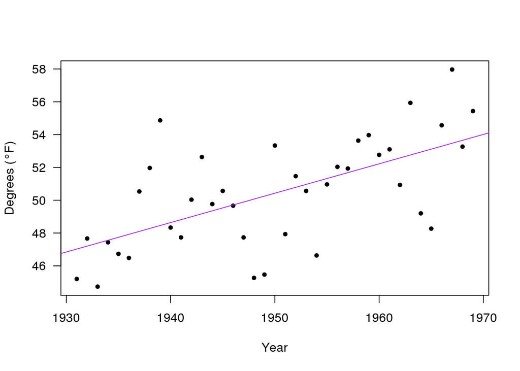

The minimum temperatures within the month of September increase at a slope of 0.18 degrees Fahrenheit per year, with a statistically significant probability of <.001. This rejects the null hypothesis by indicating a relationship between temperature rise and time.

## What is the significance of this data?

An increase in minimum temperatures in October and September likely signify an increased warmth in nights specifically, as this is when temperature is usually the coldest. This data raises a red flag for the local viticulture through these temperature’s ecologic, economic, and reputational implications for the city of Lodi.

### What is the ecological impact of increased minimum temperatures?

### Water

Higher atmospheric temperatures reduce Lodi’s groundwater supply, which is already limited and expected to be depleted (Famiglietti, 2011). Lodi and the city’s surroundings use groundwater as their main source of water, which is used for residential and irrigational purposes. With significant cuts in managed water allocations in response to the California drought, farmers particularly in the San Joaquin Valley are forced to tap heavily into the already heavily depended on groundwater reserves to meet irrigation demands. This furthers the Central Valley’s excession of the groundwater natural recharge rate (Scanlon, 2012). Given the already naturally low rates of groundwater recharge in the San Joaquin Valley and population growth, a continuance of groundwater depletion is expected (Famiglietti, 2011). Unfortunately for Lodi’s drying groundwater, the city’s surrounding San Joaquin Valley relies more heavily on groundwater than its Sacramento counterpart because the drier climate results in more limited natural surface water availability. Increased temperature and evapotranspiration results in increased domestic water use within the city, as well (Abtew, 2013). This thereby limits water sources even further. As is discussed in the next section, water limitations obstructs successful viticulture.

### Soil Moisture

As farmers’ irrigation systems are threatened due to a lack of groundwater, soil moisture suffers. In this case, there is a reduced winegrape yield, smaller berry size and reduced bud fertility (Leeuwen, 2016). In Mediterranean or very dry climates such as Lodi, wine quality may also suffer from excessive water stress (Leeuwen, 2016). In addition, soil moisture is an important control for heat and water transfer between the land and atmosphere. This in turn encourages the development of extreme heat events (Lobell, 2008). White (2006) illustrates the ways in which extreme heat events affect wine grape production in the United States, estimating in 2006 that potential premium wine grape production area in the conterminous United States could decline by up to 81% by the late 21st century due to an increase in extreme heat. This will “shift wine production to warmer climate varieties and/or lower-quality wines”.

### Riparian Ecosystems

Anthropogenic warming endangers riparian ecosystems because this affects the salmon population vital to Lodi’s riverside vineyards. Water temperatures constrain ecological function, such as fish spawning, swimming performance, metabolism, effects of aquatic invertebrates, and mortality (Wagner, 2011). Within the Sacramento-San Joaquin Delta, Chinook salmon are threatened by increased temperatures and drought years (Yates, 2008). These salmon, once in the Mokelumne River, transport biomass and nitrogen; this is key to stream and riparian ecosystem function (Merz, 2006). In fact, the studied native riparian vegetation, including vineyards, in the Mokelumne River that resided close to spawning sites received 18-25% of foliar nitrogen from marine sources. With animals feeding on salmon carcasses in the Mokelumne and salmon jawbones scattered in riparian vineyards alongside the river, researchers pointed to salmon as the source for the grape leaves’ total nitrogen. This data suggest that even in impaired watersheds, robust salmon runs provide important ecological services for viticulture specifically. Loss of Pacific salmon can not only negatively affect stream and riparian ecosystem function, but can also affect local economies where agriculture and salmon streams coexist, thereby affecting wine grape production in particular. In addition, even beyond this highly altered river that flow through agricultural areas, salmon also fertilize vineyards in other areas through irrigation water being pumped from spawning rivers.

### Diminished Cooling Period

Warmer nights threaten wine production and quality by through their reduction in wide diurnal temperature swings. While the heat of day promotes ripeness and sugar development (“Life Cycle of a Grape”) in the grapes, cool nights help the grapes to retain acidity and freshness, resulting in balanced flavors (Gershunov, 2010). To offset the sweetness given off by the warm sun, wines need the acidity metabolized when the cool night slows grape metabolism (Winkler, 1973). In addition, with the heat reducing acidity, the grapes are then more susceptible to spoilage and pests (Winkler, 1973). Farmers likely exacerbate diminishing groundwater supply in their efforts to maintain wine grape productivity and quality in the face of temperature increases through an increase water use for irrigation and the misting of water to cool down grapes. Using the Winkler Index for vineyard suitability, which evaluates an area based on growing degree days, Jones (2010) found that there are several places in California, particularly in the Central Valley (Hall, 2010), that are already bordering on “too hot” for grapes and that further warming would be detrimental for grape growing in these regions. Andrew Hall et. al in 2010 found it was found that 78% of the vineyard sites in the Lodi AVA fall into the Winkler Index Class IV (hot), with the remaining 22% falling into Class V (very hot).

## Work Cited

“California Central Valley.” AMNH. N.p., n.d. Web. 27 Feb. 2017. http://www.amnh.org/explore/curriculum-collections/grace/grace-tracking-water-from-space/california-central-valley.

“Agenda Item G-1.” (2012): n. pag. Public Documents for the City of Lodi. 2012. Web. 27 Feb. 2017.

“3.5.1 How Will Climate Change Affect the Balance of Water Demand and Water Availability?” 3.5.1 How Will Climate Change Affect the Balance of Water Demand and Water Availability? - AR4 WGII Chapter 3: Freshwater Resources and Their Management. N.p., n.d. Web. 13 Feb. 2017.

Scanlon, B. R., C. C. Faunt, L. Longue-vergne, R. C. Reedy, W. M. Alley, V. L. Mcguire, and P. B. Mcmahon. “Groundwater Depletion and Sustainability of Irrigation in the US High Plains and Central Valley.” Proceedings of the National Academy of Sciences 109.24 (2012): 9320-325. Web. 12 Feb. 2017.

Wagner, R. Wayne, Mark Stacey, Larry R. Brown, and Michael Dettinger. “Statistical Models of Temperature in the Sacramento San Joaquin Delta Under Climate-Change Scenarios and Ecological Implications.” Estuaries and Coasts 34.3 (2011): 544-56. Web.

Abtew, Wossenu, and Assefa M. Melesse. Evaporation and Evapotranspiration: Measurements and Estimations. Dordrecht: Springer, 2013. 197-202. Print.

Cayan, D., E. P. Maurer, M. D. Dettinger, M. Tyree, and K. Hayhoe (2006), Climate scenarios for California, Rep. CEC-500-2005-203-SF, 52 pp., Calif. Clim. Change Cent., Sacramento. Famiglietti, J. S., M. Lo, S. L. Ho, J. Bethune, K. J. Anderson, T. H. Syed, S. C. Swenson, C. R. de Linage, and M. Rodell (2011), Satellites measure recent rates of groundwater depletion in California’s Central Valley, Geophys. Res. Lett., 38, L03403, doi:10.1029/2010GL046442. Leeuwen, Cornelis Van, and Philippe Darriet. “The Impact of Climate Change on Viticulture and Wine Quality.” Journal of Wine Economics 11.01 (2016): 150-67. Web. 30 Mar. 2017.

Lobell D, Bala G, Mirin A, Phillips T, Maxwell R and Rotman D 2009 Regional differences in the influence of irrigation on climate J. Clim. 22 2248–55

White, M. A., N. S. Diffenbaugh, G. V. Jones, J. S. Pal, and F. Giorgi. “Extreme Heat Reduces and Shifts United States Premium Wine Production in the 21st Century.” Proceedings of the National Academy of Sciences 103.30 (2006): 11217-1222. Web. 10 Feb. 2017.

Wagner, R. Wayne, Mark Stacey, Larry R. Brown, and Michael Dettinger. “Statistical Models of Temperature in the Sacramento San Joaquin Delta Under Climate-Change Scenarios and Ecological Implications.” Estuaries and Coasts 34.3 (2011): 544-56. Web. 25 Feb. 2017.

Yates, D., H. Galbraith, D. Purkey, A. Huber-Lee, J. Sieber, J. West, S. Herrod-Julius, and B. Joyce. 2008. Climate Warming, Water Storage, and Chinook Salmon in California’s Sacramento Valley. Climatic Change 91(3-4):335-350.

Merz, J. E. and Moyle, P. B. (2006), Salmon, Wildlife, And Wine: Marine-Derived Nutrients In Human-Dominated Ecosystems Of Central California. Ecological Applications, 16: 999–1009. doi:10.1890/1051-0761(2006)016[0999:SWAWMN]2.0.CO;2

Vintners, Napa Valley. “The Life Cycle of A Grape.” Napa Valley Vintners. N.p., n.d. Web. 30 Mar. 2017. https://napavintners.com/napa_valley/life_cycle_of_a_grape.asp.

Gershunov A., D. Cayan and B. Retournaz. 2010: California Heat Waves with Impacts on Wine Grapes. In E.G. Pavia, J. Sheinbaum and J. Candela (Eds), The Ocean, the Wine, and the Valley: The Lives of Antoine Badan, Lulu Press, 205-223, ISBN 978-0-557-94026-4. Jones, G.V., Duff, A.A., Hall, A., and Myers, J.W. 2010. Spatial Analysis of Climate in Winegrape Growing Regions in the Western United States. American Journal for Enology and Viticulture 61(3): 313-326.

Hall, Andrew, Gregory Jones, Andrew Duff, and Joseph Myers. “Spatial Analysis of Climate in Winegrape Growing Regions in the Western United States.” American Journal of Enology and Viticulture (2010): n. pag. Web. 30 Mar. 2017. http://www.ajevonline.org/content/61/3/313.

Winkler, Albert Julius, Ruth Teiser, and Joann Leach Larkey. “Viticultural Research at University of California, Davis, 1921-1971.” (1973).